# Regression of building energy data

```r
library(rjags)
```

```r
library("ggplot2")
```

Loading data

```r
data <- read.csv("Energy_Efficiency.csv")
```

## Data Overview

Data consists of two responses and eight attributes:

• X1 Relative Compactness • X2 Surface Area • X3 Wall Area • X4 Roof Area • X5 Overall Height • X6 Orientation (categorical) • X7 Glazing Area • X8 Glazing Area Distribution (categorical) • y1 Heating Load • y2 Cooling Load

Renaming the columns to make them more understandable

```r
colnames(data) <- c('Relative_Compactness',
                      'Surface_Area',
                      'Wall_Area',
                      'Roof_Area',
                      'Overall_Height',
                      'Orientation',
                      'Glazing_Area',
                      'Glazing_Area_Distribution',
                      'Heating_Load',
                      'Cooling_Load')
```

```r
head(data)
```

```
##   Relative_Compactness Surface_Area Wall_Area Roof_Area Overall_Height
## 1                 0.98        514.5     294.0    110.25              7
## 2                 0.98        514.5     294.0    110.25              7
## 3                 0.98        514.5     294.0    110.25              7
## 4                 0.98        514.5     294.0    110.25              7
## 5                 0.90        563.5     318.5    122.50              7
## 6                 0.90        563.5     318.5    122.50              7
##   Orientation Glazing_Area Glazing_Area_Distribution Heating_Load Cooling_Load
## 1           2            0                         0        15.55        21.33
## 2           3            0                         0        15.55        21.33
## 3           4            0                         0        15.55        21.33
## 4           5            0                         0        15.55        21.33
## 5           2            0                         0        20.84        28.28
## 6           3            0                         0        21.46        25.38
```

```r
summary(data) #basic statistical properties for the data
```

```
##  Relative_Compactness  Surface_Area     Wall_Area       Roof_Area
##  Min.   :0.6200       Min.   :514.5   Min.   :245.0   Min.   :110.2
##  1st Qu.:0.6825       1st Qu.:606.4   1st Qu.:294.0   1st Qu.:140.9
##  Median :0.7500       Median :673.8   Median :318.5   Median :183.8
##  Mean   :0.7642       Mean   :671.7   Mean   :318.5   Mean   :176.6
##  3rd Qu.:0.8300       3rd Qu.:741.1   3rd Qu.:343.0   3rd Qu.:220.5
##  Max.   :0.9800       Max.   :808.5   Max.   :416.5   Max.   :220.5
##  Overall_Height  Orientation    Glazing_Area    Glazing_Area_Distribution
##  Min.   :3.50   Min.   :2.00   Min.   :0.0000   Min.   :0.000
##  1st Qu.:3.50   1st Qu.:2.75   1st Qu.:0.1000   1st Qu.:1.750
##  Median :5.25   Median :3.50   Median :0.2500   Median :3.000
##  Mean   :5.25   Mean   :3.50   Mean   :0.2344   Mean   :2.812
##  3rd Qu.:7.00   3rd Qu.:4.25   3rd Qu.:0.4000   3rd Qu.:4.000
##  Max.   :7.00   Max.   :5.00   Max.   :0.4000   Max.   :5.000
##   Heating_Load    Cooling_Load
##  Min.   : 6.01   Min.   :10.90
##  1st Qu.:12.99   1st Qu.:15.62
##  Median :18.95   Median :22.08
##  Mean   :22.31   Mean   :24.59
##  3rd Qu.:31.67   3rd Qu.:33.13
##  Max.   :43.10   Max.   :48.03
```

```r
str(data)     #type of data and counts
```

```
## 'data.frame':    768 obs. of  10 variables:
##  $ Relative_Compactness     : num  0.98 0.98 0.98 0.98 0.9 0.9 0.9 0.9 0.86 0.86 ...
##  $ Surface_Area             : num  514 514 514 514 564 ...
##  $ Wall_Area                : num  294 294 294 294 318 ...
##  $ Roof_Area                : num  110 110 110 110 122 ...
##  $ Overall_Height           : num  7 7 7 7 7 7 7 7 7 7 ...
##  $ Orientation              : int  2 3 4 5 2 3 4 5 2 3 ...
##  $ Glazing_Area             : num  0 0 0 0 0 0 0 0 0 0 ...
##  $ Glazing_Area_Distribution: int  0 0 0 0 0 0 0 0 0 0 ...
##  $ Heating_Load             : num  15.6 15.6 15.6 15.6 20.8 ...
##  $ Cooling_Load             : num  21.3 21.3 21.3 21.3 28.3 ...
```

Looking for Null-values in the data

```r
colSums(is.na(data))
```

```
##      Relative_Compactness              Surface_Area                 Wall_Area
##                         0                         0                         0
##                 Roof_Area            Overall_Height               Orientation
##                         0                         0                         0
##              Glazing_Area Glazing_Area_Distribution              Heating_Load
##                         0                         0                         0
##              Cooling_Load
##                         0
```

No null-values found.

## Data Visualization

```r
numerical_attributes <- c(
  'Relative_Compactness', 'Surface_Area', 'Wall_Area', 'Roof_Area',
  'Overall_Height', 'Glazing_Area'
)
```

### Histograms

Plotting histograms for both the response variables

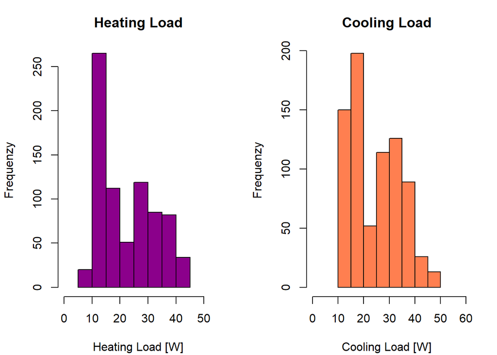

```r
old_par <- par(mfrow = c(1, 2), mar = c(4, 4, 3, 2) + 0.1)
# histogram with added parameters
heating_load <-data[['Heating_Load']]

hist(heating_load,
main="Heating Load",
xlab="Heating Load [W]",
ylab="Frequenzy",
xlim=c(0,max(heating_load)+10),
col="darkmagenta"
)

cooling_load <-data[['Cooling_Load']]

hist(cooling_load,
main="Cooling Load",
xlab="Cooling Load [W]",
ylab="Frequenzy",
xlim=c(0,max(cooling_load)+10),
col="coral"
)
```

### Boxplots

plotting boxplots for data

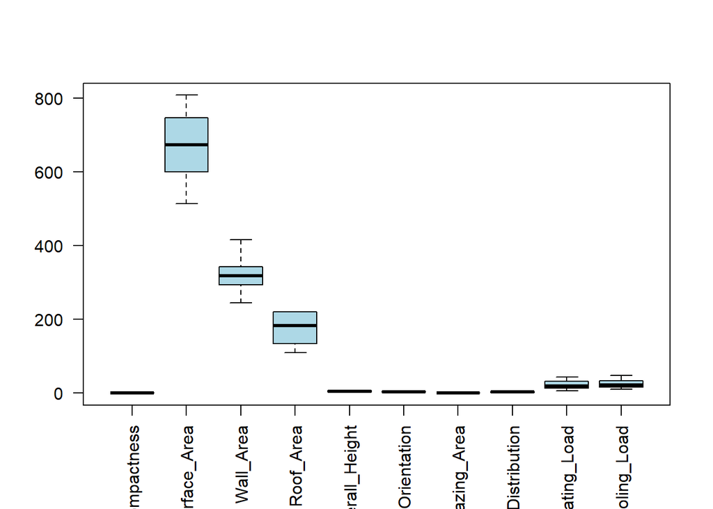

```r
boxplot(data,col="lightblue", las = 2)
```

We notice that there is a scaling problem with the data. This can cause the regression to prioritize certain features. Solution: mean-centre the data.

Looking at individual boxplots, categorical values not included

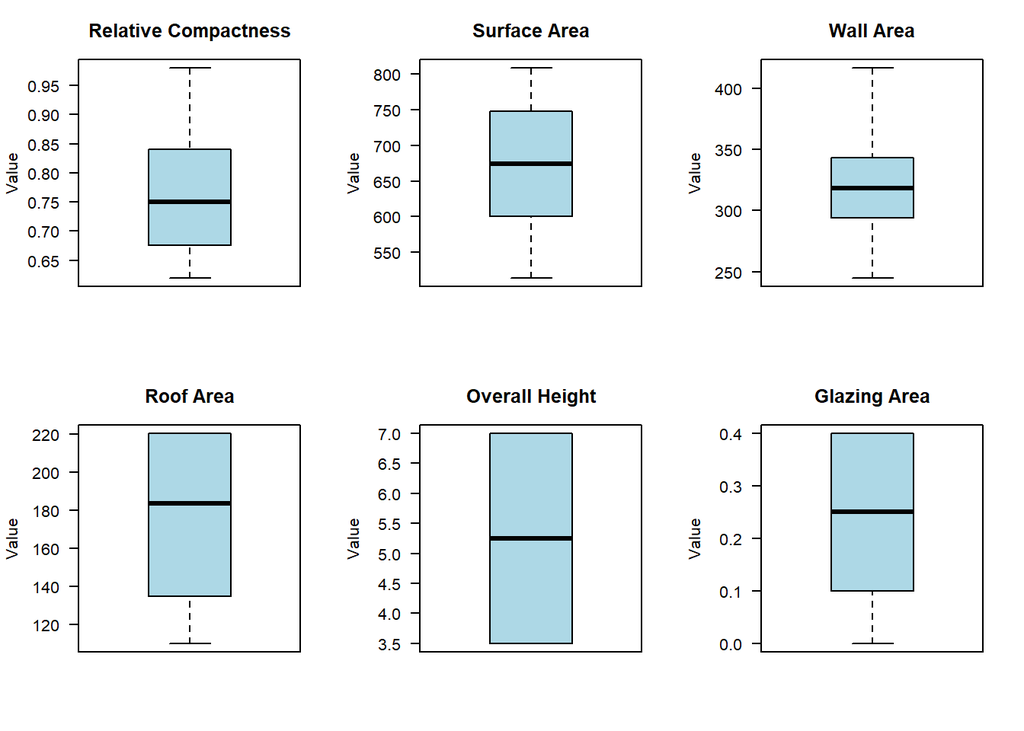

```r
# Creating a plotting layout for a grid (2 rows, 4 columns)
old_par <- par(mfrow = c(2, 3), mar = c(4, 4, 3, 2) + 0.1)

# Looping through each numerical column to create a boxplot
for (col_name in numerical_attributes) {
  boxplot(data[[col_name]],
          main = paste(gsub("_", " ", col_name)), # Title for each plot
          ylab = "Value", # Y-axis label
          col = "lightblue", # Color of the boxplot
          las = 1 # Always horizontal axis labels for values
  )
}
```

```r
par(old_par)
```

Also Roof Area, Relative Compactness and Glazing Area has a slight degree of skewness.  
Solution: use a prior distribution with a marked tail.

### Scatterplots

Categorical attributes not included

Scatterplots for Heat Load

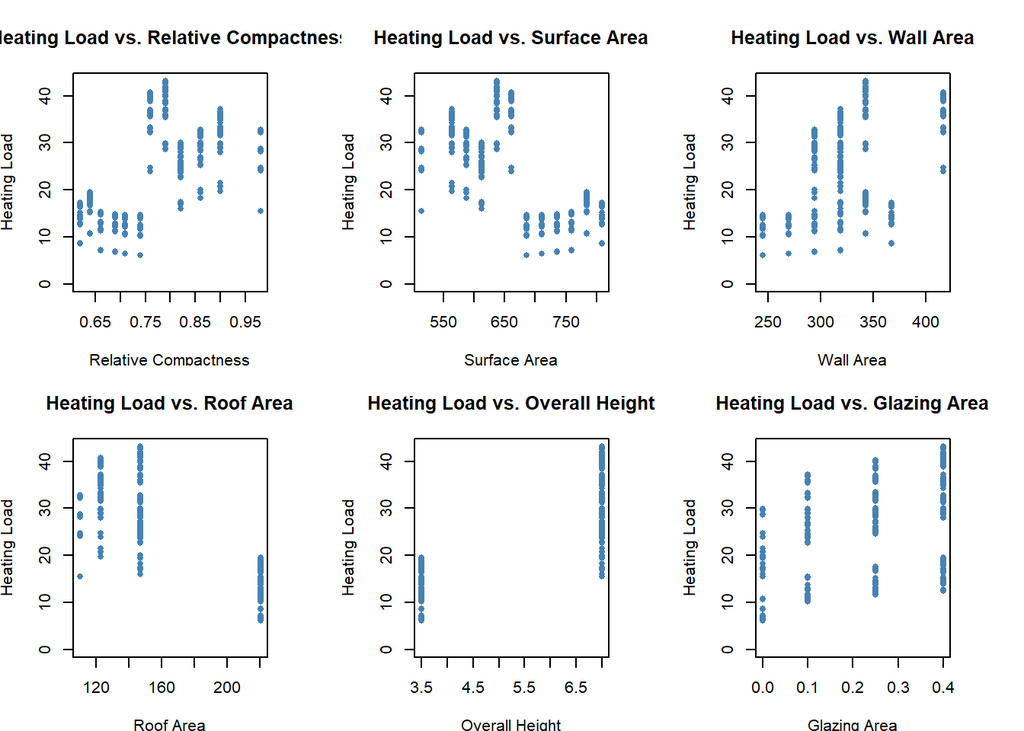

```r
old_par <- par(mfrow = c(2, 3), mar = c(0, 0, 0, 0) + 3.8)


for (predictor_col in numerical_attributes) {
    plot(data[[predictor_col]], data[["Heating_Load"]],
         xlab = gsub("_", " ", predictor_col),
         ylab = "Heating Load",
         main = paste("Heating Load", "vs.", gsub("_", " ", predictor_col)), # Dynamic title
         col = "steelblue", # Point color
         pch = 16,          # Solid circles for points
         cex = 0.8,          # Size of points
         ylim = c(0, max(data[["Heating_Load"]]))
    )
}
```

We notice highly unlinear behaviour for Relative Compactness, and Surface Area

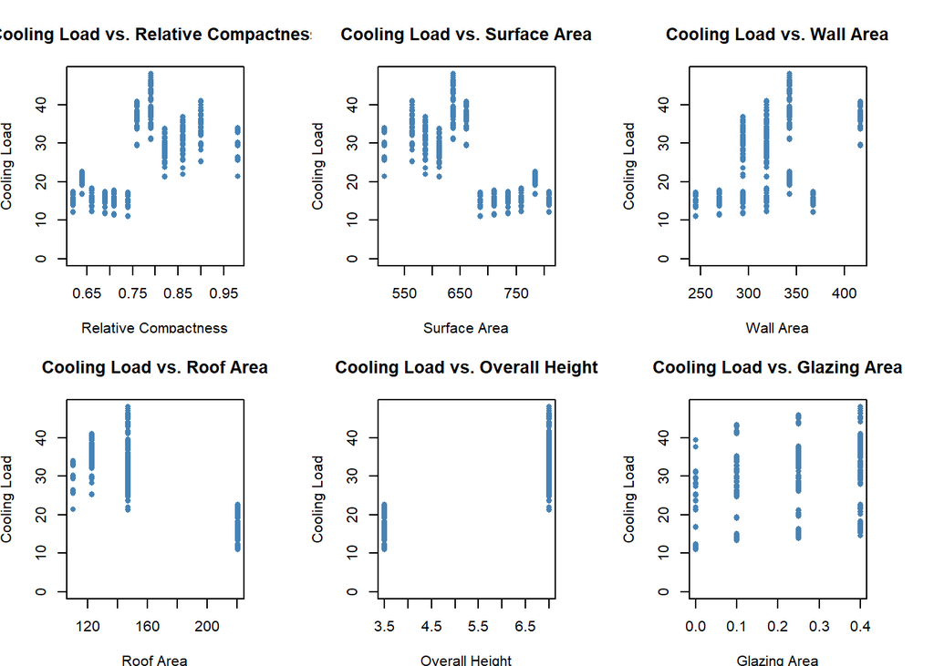

```r
old_par <- par(mfrow = c(2, 3), mar = c(0, 0, 0, 0) + 3.8)

for (predictor_col in numerical_attributes) {
    plot(data[[predictor_col]], data[["Cooling_Load"]],
         xlab = gsub("_", " ", predictor_col),
         ylab = "Cooling Load",
         main = paste("Cooling Load", "vs.", gsub("_", " ", predictor_col)), # Dynamic title
         col = "steelblue", # Point color
         pch = 16,          # Solid circles for points
         cex = 0.8,          # Size of points
         ylim = c(0, max(data[["Cooling_Load"]]))
    )
}
```

## Categorical Value Visualization

Analyzing orientation

```r
orientation_counts <- table(data[["Orientation"]]) #convert dataframe to vector
print(orientation_counts)
```

```
##
##   2   3   4   5
## 192 192 192 192
```

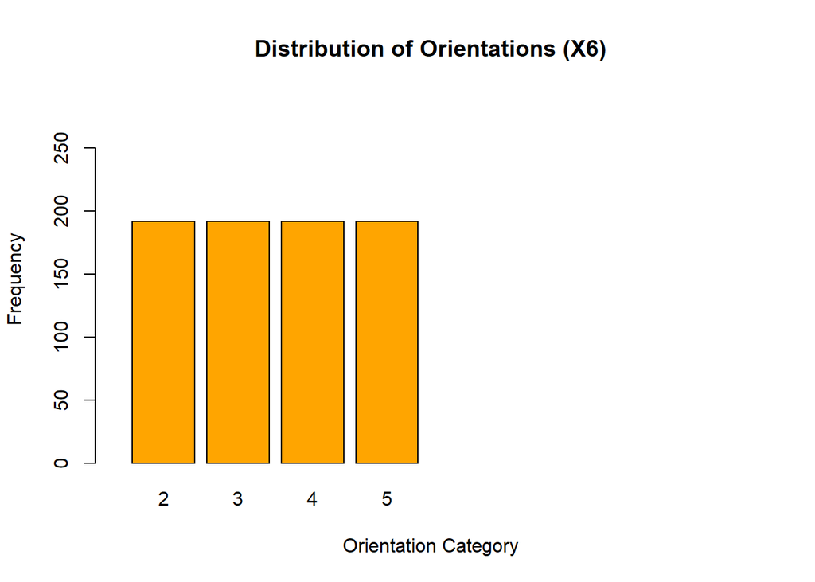

```r
barplot(orientation_counts,
        col = "orange",
        main = "Distribution of Orientations (X6)",
        xlab = "Orientation Category",
        ylab = "Frequency",
        xlim = c(0, 1),
        ylim = c(0, max(orientation_counts)+100),
        width = 0.1
        )
```

Analyzing Glazing Area Distribution

```r
glazing_area_counts <- table(data[["Glazing_Area_Distribution"]]) #convert dataframe to vector
print(glazing_area_counts)
```

```
##
##   0   1   2   3   4   5
##  48 144 144 144 144 144
```

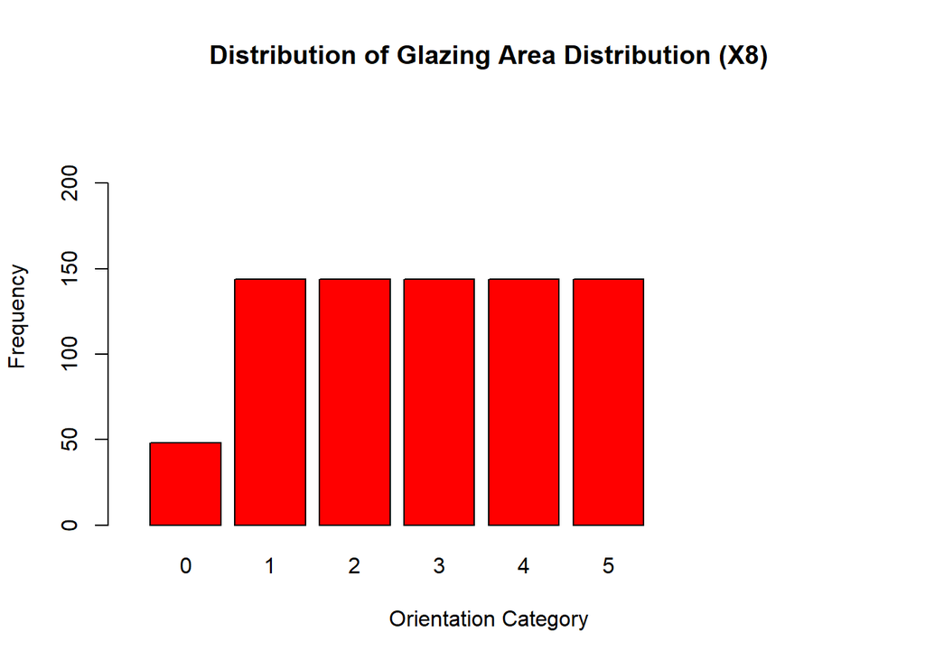

```r
barplot(glazing_area_counts,
        col = "red",
        main = "Distribution of Glazing Area Distribution (X8)",
        xlab = "Orientation Category",
        ylab = "Frequency",
        xlim = c(0, 1),
        ylim = c(0, max(glazing_area_counts)+100),
        width = 0.1
        )
```

## Preprocessing

### Convert categorical attributes

To convert categorical attributes, replace categorical attributes with m-1 indicator attributes, where m = number of categories. One variable must be removed in order for X to be invertable This can be automatically done with the as.factor function, https://www.rdocumentation.org/packages/h2o/versions/2.4.3.11/topics/as.factor

```r
transform_categorical_attributes <- function(data){

  categorical_attributes <- c('Orientation', 'Glazing_Area_Distribution')

  for(attribute in categorical_attributes){
    # Convert the column to a factor
    data[[attribute]] <- as.factor(data[[attribute]])
  }

  return(data)
}

data <- transform_categorical_attributes(data)
```

### Mean Center

We only wish to mean center non-categorical attributes, mean centering will make the final model parameters more interpretative

```r
mean_center <- function(data) {
  unscaled_cols <- list('Orientation','Glazing_Area_Distribution','Heating_Load','Cooling_Load') #list of columns to not mean center (categorical + response vars)
  for(attribute in colnames(data)){
    if(attribute %in% unscaled_cols){next}
    data[attribute] <-  as.vector(scale(data[attribute])) #mean center the data
    }
  return(data)
}

data <- mean_center(data)
```

### Split into training/test set

```r
set.seed(42)

#use 80% of dataset as training set and 20% as test set
sample <- sample(c(TRUE, FALSE), nrow(data), replace=TRUE, prob=c(0.7,0.3))
train  <- data[sample, ]
test   <- data[!sample, ]

formula_full <- Heating_Load ~ Relative_Compactness + Surface_Area + Wall_Area + Roof_Area + Overall_Height + Orientation + Glazing_Area + Glazing_Area_Distribution

# Training set
X <- model.matrix(formula_full, data = train)
y <- as.matrix(train["Heating_Load"])

#Test set
X_test <- model.matrix(formula_full, data = test)
y_test <- as.matrix(test["Heating_Load"])
```

## Model Selection

The goal of this sections is to perform linear regression in the Bayesian framework. The linear model is given by:

$$y = X\beta+\epsilon$$
where
$$\epsilon \sim \mathcal{N}(0, \sigma^2)$$

The likelihood of $y$ given $\beta$, $\sigma^2$, and $X$ is normally distributed:

$$y|\beta, \sigma^2, X \sim \mathcal{N}(X\beta, \sigma^2 I_n) \quad
\text{likelihood}$$

The prior distribution for the parameters $(\beta, \sigma^2)$ is given by $\pi(\beta, \sigma^2)$:

$$(\beta, \sigma^2) \sim \pi(\beta, \sigma^2) \quad \text{prior}$$
The objective of the analysis is to find good prior distributions.

### Conjugate prior

Conjugate priors have posteriors that can be easily calculated without simulation. However, there are many hyperparameters to tune. The prior distribution is the following:
$$\beta|\sigma^2 \sim \mathcal{N}_{k+1}(\tilde{\beta}, \sigma^2 M^{-1}),$$

#### Arbitrary values for hyper parameters

Finding the posteriror analytically:

```r
# Get the dimension, note that X already have intercept-columns
k<-ncol(X)
n<-nrow(X)

#defining hyperparameters:
a<-1    #low to get a flat distribution to account for uncertainty in prior
b<-1    #low to get a flat distribution to account for uncertainty in prior
beta_pri <- rep(0, k) #zero to account for uncertainty in prior
c<-1000 #large to account for uncertainty in prior
M <- diag(k) * c

#calculating posterior
XtX <- t(X) %*% X
beta_hat <- solve(XtX) %*% t(X) %*% y
s2 <- t(y-X %*% beta_hat) %*% (y-X%*%beta_hat)

beta_post_cm <- solve(M + XtX) %*% (XtX %*% beta_hat+M %*% beta_pri)
M_post    <- solve(M+XtX)
a_post    <- n/2 + a
b_post    <- b + s2/2 + 1/2* (t(beta_post_cm-beta_hat) %*% solve(solve(M) + solve(XtX)) %*% (beta_post_cm-beta_hat))
```

### Testing Conjugate Model

```r
predictions_conjugate_model <- X_test %*% beta_post_cm
```

### Results

using Mean Square Error to see results

```r
mse <- mean((y_test - predictions_conjugate_model)^2)
cat("Test MSE:", mse, "\n")
```

```
## Test MSE: 176.6026
```